# Blog Post - Monte Carlo Simulation

## Plots

Now, we can plot the results of absolute and relative error and observe the relationship between the absolute error and the number of replicates in the binomial distribution. On the Y-axis, the absolute error is being plotted and the X-axis is the number of replicates. The different colors represent the different probabilities being tested for.

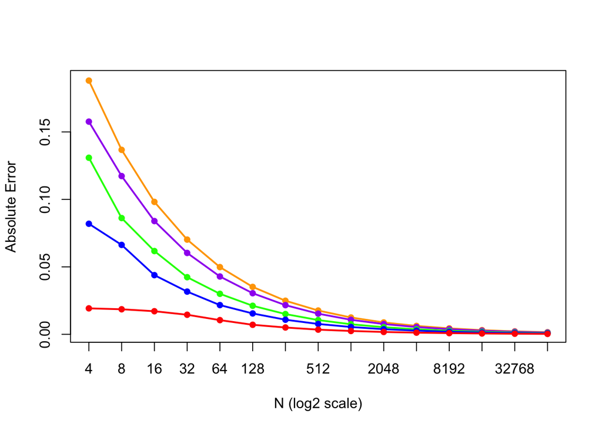

```r
plot(1:15, abs_error[,5],axes=FALSE,type="o",col="orange",xlab="N (log2 scale)", ylab= "Absolute Error", pch = 16, lwd = 2)
axis(1,1:15,R)
axis(2)
box()
lines(1:15, abs_error[,4], col= "purple",type="o", pch = 16, lwd = 2)
lines(1:15, abs_error[,3], col= "green",type="o", pch = 16, lwd = 2)
lines(1:15, abs_error[,2], col= "blue",type="o", pch = 16, lwd = 2)
lines(1:15,abs_error[,1],col= "red",type="o", pch = 16, lwd = 2)
```

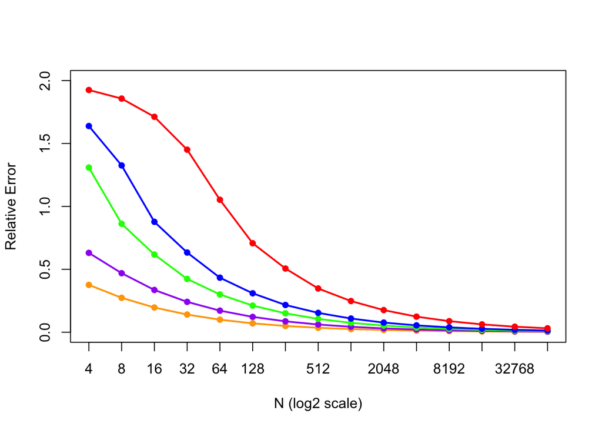

```r
plot(1:15, rel_error[,5],axes=FALSE, type="o",col="orange",xlab="N (log2 scale)", ylab= "Relative Error", ylim = c(0,2), pch = 16, lwd = 2)
axis(1,1:15,R)
axis(2)
box()
lines(1:15, rel_error[,4], col= "purple",type="o", pch = 16, lwd = 2)
lines(1:15, rel_error[,3], col= "green",type="o", pch = 16, lwd = 2)
lines(1:15, rel_error[,2], col= "blue",type="o", pch = 16, lwd = 2)
lines(1:15, rel_error[,1],col= "red",type="o", pch = 16, lwd = 2)
```

Generally, it can be seen that as the number of replicates increases, both the relative and absolute errors decrease to 0. This demonstrates that for Monte Carlo simulations, degree of error gets smaller as the number of simulation replicates increases.